# [Заметки по R](http://bdemeshev.github.io/r_cycle/): Дифференциальные уравнения

07.01.2016

```r
library("knitr")
opts_chunk$set(
  # cache=FALSE,
               message=FALSE, warning=FALSE)

library("ggplot2") # для построения графиков
library("rasterVis")
library("fields")
library("deSolve") # решение дифф. уравнений с начальными условиями
library("bvpSolve") # решение дифф. уравнений с краевыми условиями
library("dplyr") # манипуляции с данными
```

Пакет `rasterVis` предназначен для изображения данных на реальных географических картах, поэтому там нужно понятие проекции. Мы пока просто введем это шаманское заклинание

```r
proj <- CRS('+proj=longlat +datum=WGS84')
```

### Построим график векторного поля для системы:

$\left\{ \begin{array}{l} \dot{y}_1=y_2 \\ \dot{y}_2=y_1+\cos(y_2) \end{array} \right.$

Задаем решетку, и рассчитываем $\dot{y}_1$ и $\dot{y}_2$ в точках решетки:

```r
y1 <- seq(-6, 6, 0.05)
y2 <- seq(-6, 6, 0.05)
df <- expand.grid(y1 = y1, y2 = y2)
df <- mutate(df, y1dot = y2, y2dot = y1 + cos(y2))
```

Рассчитываем длины и углы для стрелочек, помещаем результат в объект `Raster`.

```r
df <- mutate(df, len = sqrt(y1dot^2 + y2dot^2),
             angle = atan2(y1dot, y2dot))

df2 <- df[c("y1", "y2", "len", "angle")]

rast <- rasterFromXYZ(df2, crs = proj)
```

Строим классический график со стрелочками

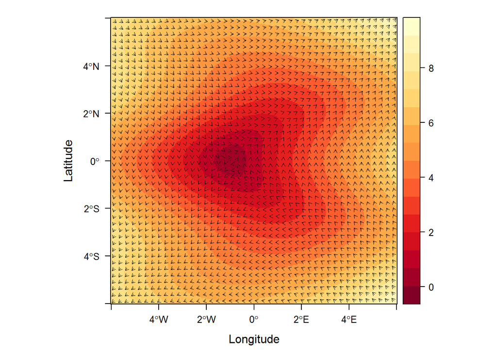

```r
vectorplot(rast, isField = TRUE)
```

Строим няку с капельками

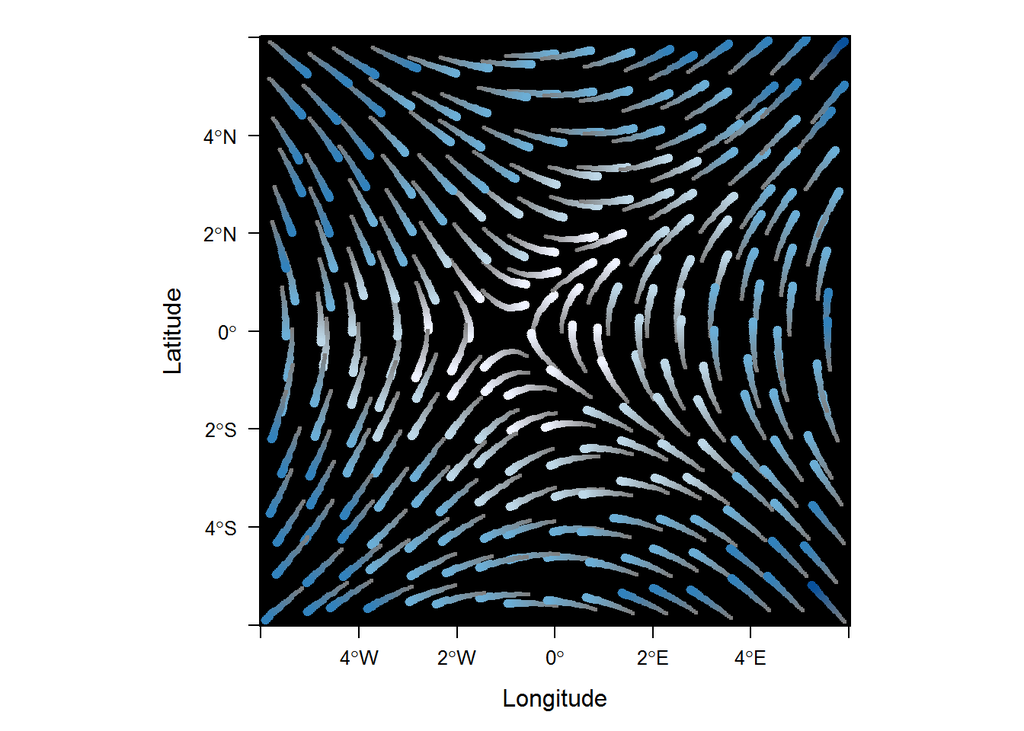

```r
streamplot(rast, isField = TRUE)
```

Простой график можно руками построить без доп. пакетов. При этом нам нужно самостоятельно уменьшить количество стрелочек.

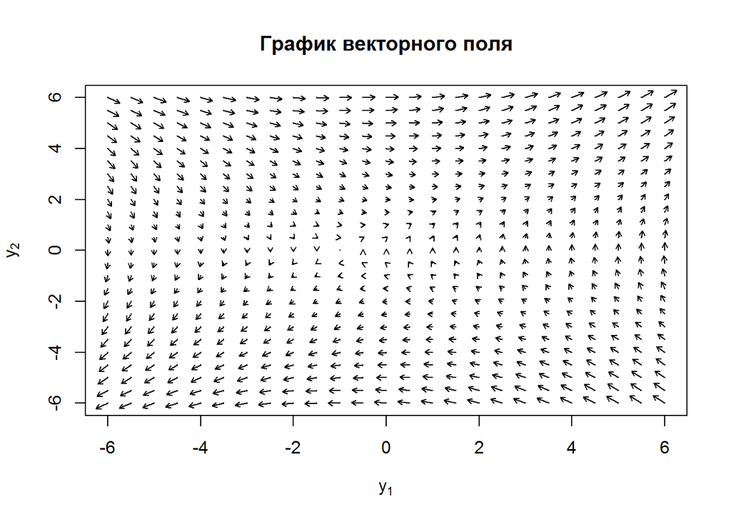

```r
y1 <- seq(-6, 6, 0.5)
y2 <- seq(-6, 6, 0.5)
df <- expand.grid(y1 = y1, y2 = y2)
df <- mutate(df, y1dot = y2, y2dot = y1 + cos(y2))
plot(df$y1, df$y2, pch = ".", xlab = expression(paste(y[1])),
  ylab = expression(paste(y[2])), main = "График векторного поля")
arrow.plot(df$y1, df$y2, df$y1dot, df$y2dot,
            arrow.ex = 0.03, length = 0.05)
```

### Решим ОДУ с начальным условиями

### Решим систему ОДУ с начальными условиями

Описываем саму систему:

```r
eq1 <- function(t, y, parampampam) {
  return(list(c(
    y[2],
    y[1] + cos(y[2])
  )))
}
```

Начальные условия:

```r
y.start <- c(y1 = 1, y2 = 4)
```

Точки, в которых компьютер будет считать функцию:

```r
t <- seq(0, 10, by = 0.01)
```

Решаем

```r
sol <- ode(y = y.start, times = t, func = eq1)
sol <- data.frame(sol)
head(sol)
```

```
##   time       y1       y2
## 1 0.00 1.000000 4.000000
## 2 0.01 1.040018 4.003678
## 3 0.02 1.080076 4.007785
## 4 0.03 1.120176 4.012326
## 5 0.04 1.160324 4.017305
## 6 0.05 1.200524 4.022725
```

```r
str(sol)
```

```
## 'data.frame':    1001 obs. of  3 variables:
##  $ time: num  0 0.01 0.02 0.03 0.04 0.05 0.06 0.07 0.08 0.09 ...
##  $ y1  : num  1 1.04 1.08 1.12 1.16 ...
##  $ y2  : num  4 4 4.01 4.01 4.02 ...
```

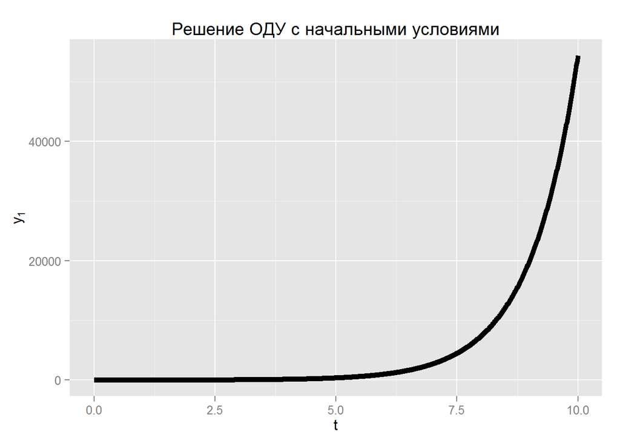

```r
ggplot(sol) + geom_line(aes(time, y1), size = 2) + labs(x = "t",
  y = expression(paste(y[1])), title = "Решение ОДУ с начальными условиями")
```

Функция `ode` возвращает матрицу, а для рисования графиков удобнее табличка с данными, data.frame. Строчка `sol <- data.frame(sol)` переделывает матрицу в таблицу с данными.

### Решим систему ОДУ с краевыми условиями

Описываем саму систему:

```r
eq1 <- function(t, y, parampampam) {
  return(list(c(
    y[2],
    y[1] + cos(y[2])
  )))
}
```

Граничные условия:

```r
y.start <- c(y1 = 1, y2 = NA)
y.final <- c(y1 = 42, y2 = NA)
```

Точки, в которых компьютер будет считать функцию:

```r
t <- seq(0, 10, by = 0.01)
```

Решаем

```r
sol <- bvptwp(yini = y.start, yend = y.final,
           x = t, func = eq1,
           nmax = 2000)
sol <- data.frame(sol)
head(sol)
```

```
##      x        y1        y2
## 1 0.00 1.0000000 -1.553150
## 2 0.01 0.9845193 -1.543001
## 3 0.02 0.9691398 -1.532904
## 4 0.03 0.9538610 -1.522860
## 5 0.04 0.9386824 -1.512868
## 6 0.05 0.9236035 -1.502928
```

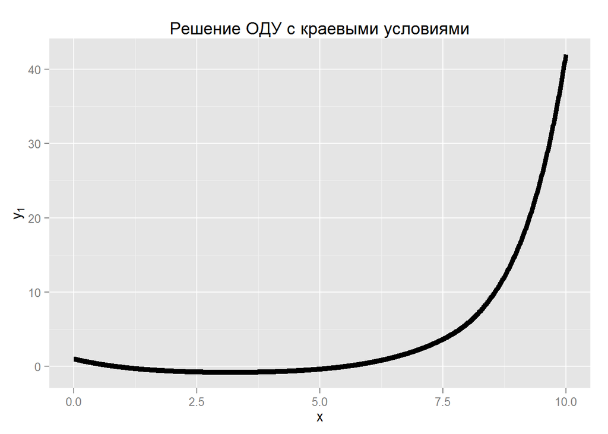

```r
ggplot(sol) + geom_line(aes(x, y1), size = 2) +  labs(x = "x",
  y = expression(paste(y[1])), title = "Решение ОДУ с краевыми условиями")
```

### Бесплатное приложение. Изображение функций двух переменных

Есть несколько способов представить себе функцию от двух переменных, $z(x, y)$:

- 3D график
- Линии уровня
- Векторное поле градиентов функции

Создаем data.frame с декартовым произведением двух векторов

```r
df <- expand.grid(x = seq(-2, 2, 0.01), y = seq(-2, 2, 0.01))
```

Изобразим функцию $z(x,y)=(3\cdot x^2+y)\cdot e^{-x^2-y^2}$.

Cоздаем переменную z как функцию от x и y

```r
df <- mutate(df, z = (3 * x^2 + y) * exp(- x^2 - y^2))
```

```r
r <- rasterFromXYZ(df, crs = proj)
```

Линии уровня функции z

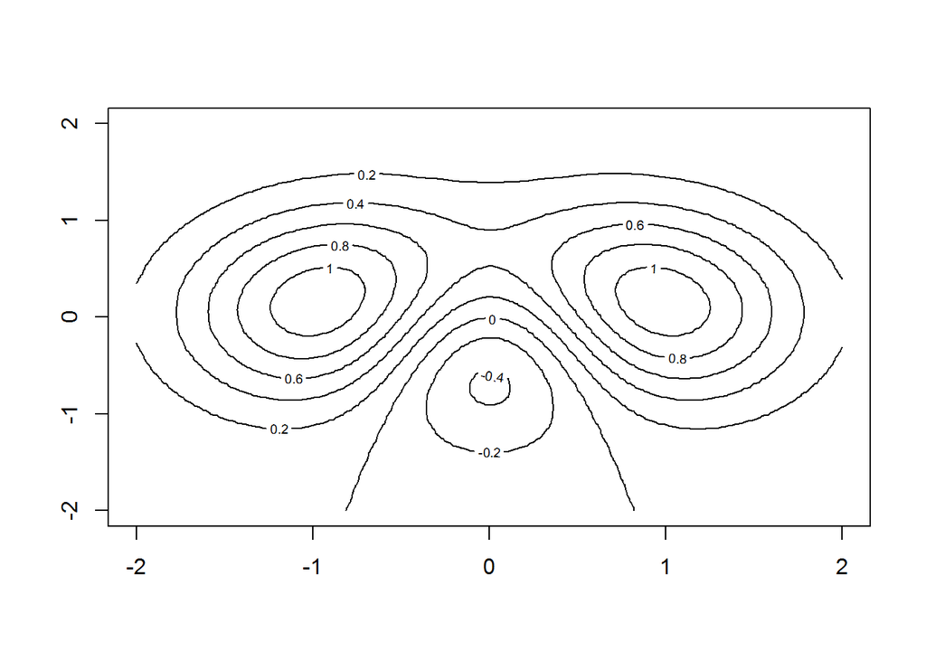

```r
contour(r)
```

Капельки текущие по градиенту

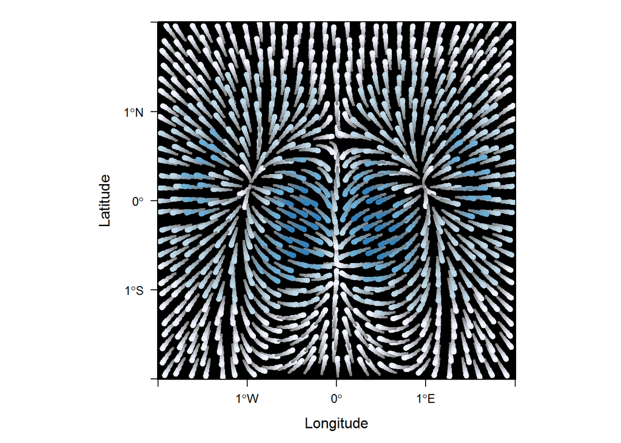

```r
streamplot(r)
```

Направление градиентов, заодно вид сбоку для графика функции

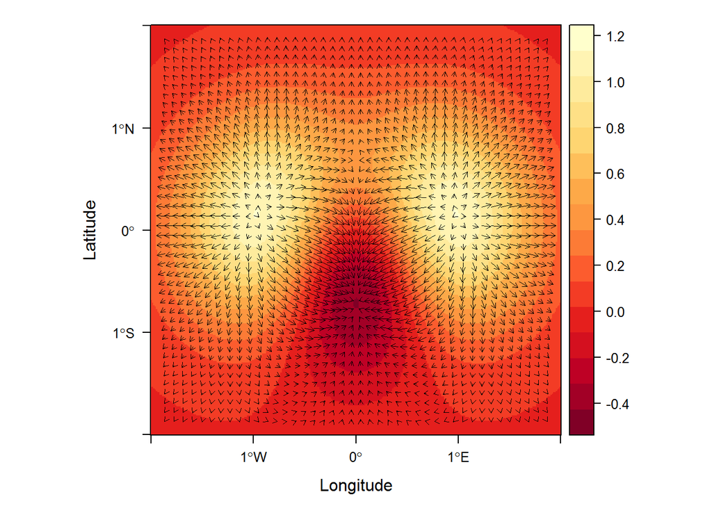

```r
vectorplot(r)
```